# RCourse

Robert Gulotty

9/30/2016

## Week 1: Intro to data.frame

The first time you run R, you will have to install packages. You install them by running the following commands:

```r
install.packages("dplyr", repos="http://cran.rstudio.com/")
install.packages("ggplot2", repos="http://cran.rstudio.com/")
install.packages("nycflights13", repos="http://cran.rstudio.com/")
```

After installation, you can load the packages with the library command.

```r
library(dplyr, warn.conflicts = F)
library(ggplot2)
library(nycflights13)
```

### Data Description

We begin by identifying the `dimensions’ of the flights dataset, which is loaded into R when you load the nycflights library

```r
dim(flights)
```

```
## [1] 336776     19
```

What do you think these numbers refer to? A little heuristic, whenever dealing with a matrix or dataframe is that the order is Rows and Columns, or Rum and Coke, Roman Catholic. R x C.

The most common command that I use is a command that glimpses the top of a dataset, called head()

```r
head(flights)
```

```
## # A tibble: 6 × 19
##    year month   day dep_time sched_dep_time dep_delay arr_time
##   <int> <int> <int>    <int>          <int>     <dbl>    <int>
## 1  2013     1     1      517            515         2      830
## 2  2013     1     1      533            529         4      850
## 3  2013     1     1      542            540         2      923
## 4  2013     1     1      544            545        -1     1004
## 5  2013     1     1      554            600        -6      812
## 6  2013     1     1      554            558        -4      740
## # ... with 12 more variables: sched_arr_time <int>, arr_delay <dbl>,
## #   carrier <chr>, flight <int>, tailnum <chr>, origin <chr>, dest <chr>,
## #   air_time <dbl>, distance <dbl>, hour <dbl>, minute <dbl>,
## #   time_hour <dttm>
```

```r
# head(flights, n=8)
```

Note that you get the first 6 rows by default. You can change this by adding to the head command an additional parameter “n”.

### Dplyr Commands

The first command to learn in the dplyr framework is filter. Filter grabs a subset of rows that satisfy logical conditions listed after the data frame. Here, we are grabbing the flights where on the day is equal to 1 and the month is equal to 1, which is to say all the flights on new years day of 2013.

```r
filter(flights, month == 1, day == 1)
```

```
## # A tibble: 842 × 19
##     year month   day dep_time sched_dep_time dep_delay arr_time
##    <int> <int> <int>    <int>          <int>     <dbl>    <int>
## 1   2013     1     1      517            515         2      830
## 2   2013     1     1      533            529         4      850
## 3   2013     1     1      542            540         2      923
## 4   2013     1     1      544            545        -1     1004
## 5   2013     1     1      554            600        -6      812
## 6   2013     1     1      554            558        -4      740
## 7   2013     1     1      555            600        -5      913
## 8   2013     1     1      557            600        -3      709
## 9   2013     1     1      557            600        -3      838
## 10  2013     1     1      558            600        -2      753
## # ... with 832 more rows, and 12 more variables: sched_arr_time <int>,
## #   arr_delay <dbl>, carrier <chr>, flight <int>, tailnum <chr>,
## #   origin <chr>, dest <chr>, air_time <dbl>, distance <dbl>, hour <dbl>,
## #   minute <dbl>, time_hour <dttm>
```

```r
filter(flights, month == 1 , day == 1, dest=="ORD" | dest== "MDW" )
```

```
## # A tibble: 56 × 19
##     year month   day dep_time sched_dep_time dep_delay arr_time
##    <int> <int> <int>    <int>          <int>     <dbl>    <int>
## 1   2013     1     1      554            558        -4      740
## 2   2013     1     1      558            600        -2      753
## 3   2013     1     1      608            600         8      807
## 4   2013     1     1      629            630        -1      824
## 5   2013     1     1      656            700        -4      854
## 6   2013     1     1      709            700         9      852
## 7   2013     1     1      715            713         2      911
## 8   2013     1     1      739            745        -6      918
## 9   2013     1     1      749            710        39      939
## 10  2013     1     1      828            830        -2     1027
## # ... with 46 more rows, and 12 more variables: sched_arr_time <int>,
## #   arr_delay <dbl>, carrier <chr>, flight <int>, tailnum <chr>,
## #   origin <chr>, dest <chr>, air_time <dbl>, distance <dbl>, hour <dbl>,
## #   minute <dbl>, time_hour <dttm>
```

Now you try:

How many flights traveled to Des Moines International from New York in August? Remove the # to make it run.

```r
# dim(filter( flights, month ==  ____ ,  ____ == "DSM"))
```

*Q. When did a flight go to Lexington, KY (LEX)?*

### Base R version

In “base” or unmodified R, all this would be more cumbersome, with the following command used to grab new years flights.

```r
flights[flights[ , "month" ] == 1 & flights[ , "day" ] == 1, ]
```

Althought we will use the dplyr commands, it is useful to learn abit about the R syntax here. Lets try to break up this cumbersome command into its parts.

The first thing to do is to start on the outside and work your way in. The outermost command is the square bracket [].

flights[] is just the whole flights dataset, and inside the square brackets are a comma. What do you think we get when we type flights[ 4 , 4 ] ?

Were you right? Try changing the numbers.

As you can see, we have a way to get elements out of the dataframe. What do you think we get when we write, - flights[ , “dest” ] or

- flights[ , “day” ]

Remember, rows and columns.

Now lets say we want the 4th entry under month, we could just write

- flights[4 , “month” ]

All of this indexing assumes we know in advance what index we are looking for. In practical terms though, we want to be able to search through the data to find specific entries.

For the next couple exercises, lets work with a subset of the data, lets examine flight patterns from New York into DC on January 18-21. Dont worry about the commands, we will explian each one. Whenever you see a `<-’ this means we are creating a new variable. filter() is the command from before, c( ) makes a list, and A %in% B reports TRUE for each element of A present somewhere in B.

```r
DCflights <- filter(flights, month==1, day %in% 18:21, dest %in% c("IAD", "DCA") )
```

Within the DC flights, suppose we want to get the longest flights. First we need to grab the air time variable, which we could do using the [] , DCflights[, “air_time”]

As a short cut, R allows us to use the $ operator to get named variables from a dataset. DCflights$air_time

Now we want the max of this list. Note we need to put in the list, and a seperate command for how to deal with missing data indicated by NA.

```r
max(DCflights$air_time, na.rm=T)
```

```
## [1] 61
```

It seems that the max is 61. Lets find out where that is true.

```r
DCflights$air_time==61
```

```
##   [1] FALSE FALSE FALSE FALSE FALSE FALSE FALSE FALSE FALSE FALSE FALSE
##  [12] FALSE FALSE FALSE FALSE FALSE FALSE FALSE FALSE FALSE FALSE FALSE
##  [23] FALSE FALSE FALSE FALSE FALSE FALSE FALSE FALSE FALSE FALSE FALSE
##  [34] FALSE FALSE FALSE FALSE FALSE FALSE FALSE FALSE FALSE FALSE FALSE
##  [45] FALSE FALSE FALSE FALSE FALSE    NA FALSE FALSE FALSE FALSE FALSE
##  [56] FALSE FALSE FALSE FALSE FALSE FALSE FALSE FALSE FALSE FALSE FALSE
##  [67] FALSE FALSE FALSE FALSE FALSE FALSE FALSE FALSE FALSE FALSE FALSE
##  [78] FALSE FALSE FALSE FALSE FALSE FALSE FALSE FALSE FALSE FALSE FALSE
##  [89] FALSE FALSE FALSE  TRUE FALSE FALSE FALSE FALSE FALSE FALSE FALSE
## [100] FALSE FALSE FALSE FALSE FALSE FALSE FALSE FALSE FALSE FALSE FALSE
## [111] FALSE FALSE FALSE FALSE FALSE FALSE FALSE FALSE FALSE FALSE FALSE
## [122] FALSE FALSE FALSE FALSE FALSE FALSE FALSE FALSE FALSE FALSE FALSE
## [133] FALSE FALSE FALSE FALSE FALSE FALSE FALSE FALSE FALSE FALSE FALSE
## [144] FALSE FALSE FALSE FALSE FALSE FALSE FALSE FALSE FALSE FALSE FALSE
## [155] FALSE FALSE FALSE FALSE FALSE FALSE FALSE    NA
```

What we really want is the ‘index’ of the flights that are 61 minutes long. For that we can use the which() command

```r
which(DCflights$air_time == 61)
```

```
## [1] 92
```

This gave us the index of the dataset where this is true, here the 92nd row. Finally, we can use this information in five ways to get that row of the dataset:

```r
DCflights[92, ]
```

```
## # A tibble: 1 × 19
##    year month   day dep_time sched_dep_time dep_delay arr_time
##   <int> <int> <int>    <int>          <int>     <dbl>    <int>
## 1  2013     1    20     1421           1429        -8     1552
## # ... with 12 more variables: sched_arr_time <int>, arr_delay <dbl>,
## #   carrier <chr>, flight <int>, tailnum <chr>, origin <chr>, dest <chr>,
## #   air_time <dbl>, distance <dbl>, hour <dbl>, minute <dbl>,
## #   time_hour <dttm>
```

```r
DCflights[which(DCflights$air_time == 61), ]
```

```
## # A tibble: 1 × 19
##    year month   day dep_time sched_dep_time dep_delay arr_time
##   <int> <int> <int>    <int>          <int>     <dbl>    <int>
## 1  2013     1    20     1421           1429        -8     1552
## # ... with 12 more variables: sched_arr_time <int>, arr_delay <dbl>,
## #   carrier <chr>, flight <int>, tailnum <chr>, origin <chr>, dest <chr>,
## #   air_time <dbl>, distance <dbl>, hour <dbl>, minute <dbl>,
## #   time_hour <dttm>
```

```r
DCflights[DCflights$air_time == 61, ]
```

```
## # A tibble: 3 × 19
##    year month   day dep_time sched_dep_time dep_delay arr_time
##   <int> <int> <int>    <int>          <int>     <dbl>    <int>
## 1    NA    NA    NA       NA             NA        NA       NA
## 2  2013     1    20     1421           1429        -8     1552
## 3    NA    NA    NA       NA             NA        NA       NA
## # ... with 12 more variables: sched_arr_time <int>, arr_delay <dbl>,
## #   carrier <chr>, flight <int>, tailnum <chr>, origin <chr>, dest <chr>,
## #   air_time <dbl>, distance <dbl>, hour <dbl>, minute <dbl>,
## #   time_hour <dttm>
```

```r
DCflights[DCflights$air_time == max(DCflights$air_time, na.rm=T), ]
```

```
## # A tibble: 3 × 19
##    year month   day dep_time sched_dep_time dep_delay arr_time
##   <int> <int> <int>    <int>          <int>     <dbl>    <int>
## 1    NA    NA    NA       NA             NA        NA       NA
## 2  2013     1    20     1421           1429        -8     1552
## 3    NA    NA    NA       NA             NA        NA       NA
## # ... with 12 more variables: sched_arr_time <int>, arr_delay <dbl>,
## #   carrier <chr>, flight <int>, tailnum <chr>, origin <chr>, dest <chr>,
## #   air_time <dbl>, distance <dbl>, hour <dbl>, minute <dbl>,
## #   time_hour <dttm>
```

```r
filter(DCflights, air_time==max(air_time, na.rm=T))
```

```
## # A tibble: 1 × 19
##    year month   day dep_time sched_dep_time dep_delay arr_time
##   <int> <int> <int>    <int>          <int>     <dbl>    <int>
## 1  2013     1    20     1421           1429        -8     1552
## # ... with 12 more variables: sched_arr_time <int>, arr_delay <dbl>,
## #   carrier <chr>, flight <int>, tailnum <chr>, origin <chr>, dest <chr>,
## #   air_time <dbl>, distance <dbl>, hour <dbl>, minute <dbl>,
## #   time_hour <dttm>
```

## An aside on indexing

One note on indexing, it is very powerful. Take the following list, for example.

```r
lengths <- c("short", "medium", "long")

lengths[c(1,1,1,1,1,1,2,2,2,3,3,3,1,1,2,3)]
```

```
##  [1] "short"  "short"  "short"  "short"  "short"  "short"  "medium"
##  [8] "medium" "medium" "long"   "long"   "long"   "short"  "short"
## [15] "medium" "long"
```

# Christmas Eve Analysis

Now, I am not sure if you are have ever taken a flight on Christmas Eve, but the pilots often fly by one another with their lights set up in a Rudolf leading the raindeer, with a red light up front, and they make an announcement for the children. Lets see if we can discover something about those flights.

```r
filter(flights, month==12, day ==24 )
```

```
## # A tibble: 761 × 19
##     year month   day dep_time sched_dep_time dep_delay arr_time
##    <int> <int> <int>    <int>          <int>     <dbl>    <int>
## 1   2013    12    24        9           2359        10      444
## 2   2013    12    24      458            500        -2      652
## 3   2013    12    24      513            515        -2      813
## 4   2013    12    24      543            540         3      844
## 5   2013    12    24      546            550        -4     1032
## 6   2013    12    24      555            600        -5      851
## 7   2013    12    24      556            600        -4      845
## 8   2013    12    24      557            600        -3      908
## 9   2013    12    24      558            600        -2      827
## 10  2013    12    24      558            600        -2      729
## # ... with 751 more rows, and 12 more variables: sched_arr_time <int>,
## #   arr_delay <dbl>, carrier <chr>, flight <int>, tailnum <chr>,
## #   origin <chr>, dest <chr>, air_time <dbl>, distance <dbl>, hour <dbl>,
## #   minute <dbl>, time_hour <dttm>
```

Lets find the flights at night, lets say after 7:00 PM, or 1900

```r
ChristmasEveFlights <- filter(flights, month==12, day ==24,  dep_time > 1900 )
```

Now lets see who was in the air long enough to see the raindeer. To do so, we will add a new variable, flighttime, by subtracting deptime from arrtime. We will add that variable using the mutate() command.

```r
ChristmasEveFlights <- mutate(ChristmasEveFlights, flighttime = arr_time - dep_time)
```

## Plotting Flights

Lets use a simple plot to visualize these flights. Remember you can learn about all commands using ?qplot

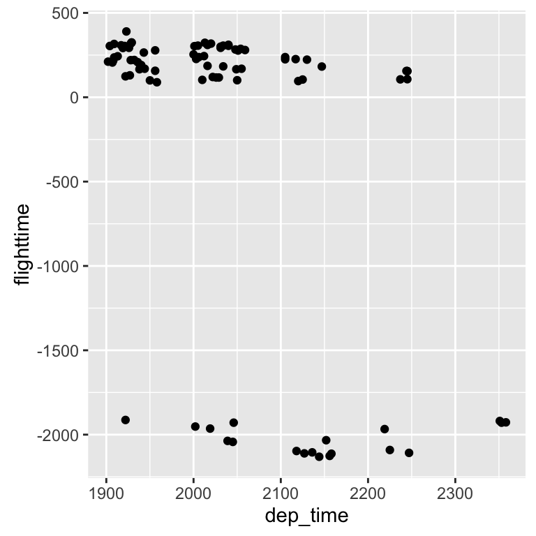

```r
qplot(x = dep_time, y = flighttime, data=ChristmasEveFlights)
```

It seems like something is wrong. Some flights are spilling over into the next day. Lets return to the Christmas Eve Flights equation. What do we need to do? We want to add 2400 hours when the flighttime is negative. We can do that with an ifelse command. ifelse commands take a logical statment and return the second element if it is true and the third element if it is false.

```r
ifelse(2==3, "Is correct", "Is not correct")
```

```
## [1] "Is not correct"
```

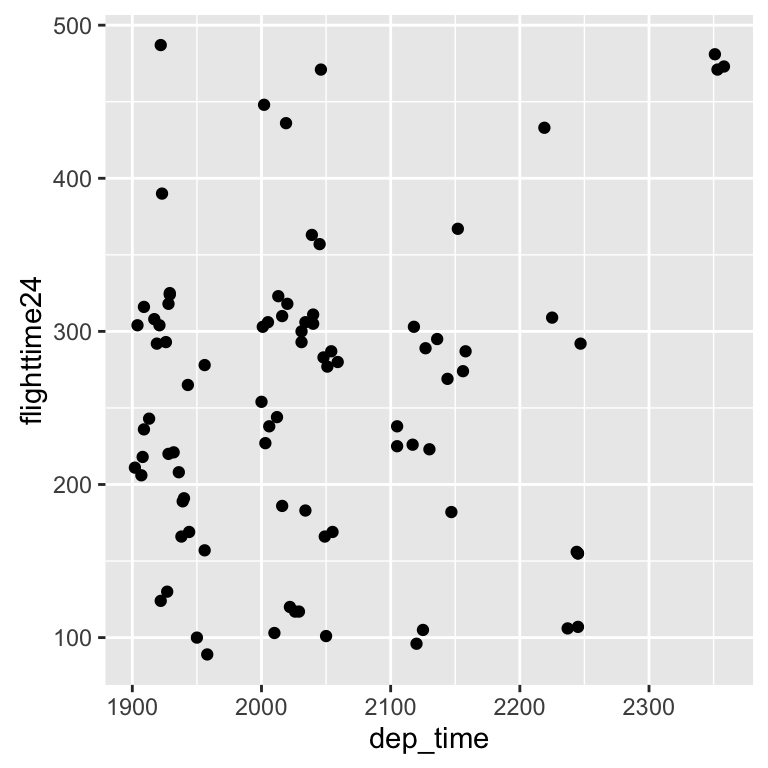

```r
ChristmasEveFlights <- mutate(ChristmasEveFlights, flighttime = arr_time - dep_time, flighttime24 = ifelse( flighttime < 0, flighttime+2400, flighttime))

qplot(dep_time, flighttime24, data=ChristmasEveFlights)
```

## Summarizing the Data

Is this an atypical distribution? Lets get some simple statistics from this distribution.

```r
summary(ChristmasEveFlights)
```

```
##       year          month         day        dep_time    sched_dep_time
##  Min.   :2013   Min.   :12   Min.   :24   Min.   :1902   Min.   :1530
##  1st Qu.:2013   1st Qu.:12   1st Qu.:24   1st Qu.:1938   1st Qu.:1930
##  Median :2013   Median :12   Median :24   Median :2022   Median :2021
##  Mean   :2013   Mean   :12   Mean   :24   Mean   :2041   Mean   :2020
##  3rd Qu.:2013   3rd Qu.:12   3rd Qu.:24   3rd Qu.:2118   3rd Qu.:2116
##  Max.   :2013   Max.   :12   Max.   :24   Max.   :2358   Max.   :2359
##    dep_delay         arr_time    sched_arr_time   arr_delay
##  Min.   :-14.00   Min.   :   2   Min.   :   3   Min.   :-46.000
##  1st Qu.: -5.00   1st Qu.:2054   1st Qu.:1962   1st Qu.:-16.000
##  Median : -1.00   Median :2208   Median :2203   Median : -6.000
##  Mean   : 12.64   Mean   :1773   Mean   :1738   Mean   :  3.609
##  3rd Qu.:  8.50   3rd Qu.:2318   3rd Qu.:2281   3rd Qu.:  7.500
##  Max.   :286.00   Max.   :2400   Max.   :2359   Max.   :251.000
##    carrier              flight         tailnum             origin
##  Length:87          Min.   :  21.0   Length:87          Length:87
##  Class :character   1st Qu.: 437.5   Class :character   Class :character
##  Mode  :character   Median :1203.0   Mode  :character   Mode  :character
##                     Mean   :1397.1
##                     3rd Qu.:2149.0
##                     Max.   :4113.0
##      dest              air_time        distance           hour
##  Length:87          Min.   : 33.0   Min.   : 187.0   Min.   :15.0
##  Class :character   1st Qu.: 86.0   1st Qu.: 515.5   1st Qu.:19.0
##  Mode  :character   Median :146.0   Median :1023.0   Median :20.0
##                     Mean   :162.6   Mean   :1129.7   Mean   :19.9
##                     3rd Qu.:199.0   3rd Qu.:1598.0   3rd Qu.:21.0
##                     Max.   :352.0   Max.   :2586.0   Max.   :23.0
##      minute        time_hour                     flighttime
##  Min.   : 0.00   Min.   :2013-12-24 15:00:00   Min.   :-2131.0
##  1st Qu.:16.00   1st Qu.:2013-12-24 19:00:00   1st Qu.:  100.5
##  Median :30.00   Median :2013-12-24 20:00:00   Median :  189.0
##  Mean   :30.23   Mean   :2013-12-24 19:53:47   Mean   : -267.8
##  3rd Qu.:45.00   3rd Qu.:2013-12-24 21:00:00   3rd Qu.:  281.5
##  Max.   :59.00   Max.   :2013-12-24 23:00:00   Max.   :  390.0
##   flighttime24
##  Min.   : 89.0
##  1st Qu.:182.5
##  Median :269.0
##  Mean   :256.3
##  3rd Qu.:307.0
##  Max.   :487.0
```

The average flight time on Christmas Eve is 256. Lets do the same calculation for the whole dataset.

```r
flights <- mutate(flights,  flighttime = arr_time - dep_time, flighttime24 = ifelse( flighttime < 0, flighttime+2400, flighttime))

summary(flights)
```

```
##       year          month             day           dep_time
##  Min.   :2013   Min.   : 1.000   Min.   : 1.00   Min.   :   1
##  1st Qu.:2013   1st Qu.: 4.000   1st Qu.: 8.00   1st Qu.: 907
##  Median :2013   Median : 7.000   Median :16.00   Median :1401
##  Mean   :2013   Mean   : 6.549   Mean   :15.71   Mean   :1349
##  3rd Qu.:2013   3rd Qu.:10.000   3rd Qu.:23.00   3rd Qu.:1744
##  Max.   :2013   Max.   :12.000   Max.   :31.00   Max.   :2400
##                                                  NA's   :8255
##  sched_dep_time   dep_delay          arr_time    sched_arr_time
##  Min.   : 106   Min.   : -43.00   Min.   :   1   Min.   :   1
##  1st Qu.: 906   1st Qu.:  -5.00   1st Qu.:1104   1st Qu.:1124
##  Median :1359   Median :  -2.00   Median :1535   Median :1556
##  Mean   :1344   Mean   :  12.64   Mean   :1502   Mean   :1536
##  3rd Qu.:1729   3rd Qu.:  11.00   3rd Qu.:1940   3rd Qu.:1945
##  Max.   :2359   Max.   :1301.00   Max.   :2400   Max.   :2359
##                 NA's   :8255      NA's   :8713
##    arr_delay          carrier              flight       tailnum
##  Min.   : -86.000   Length:336776      Min.   :   1   Length:336776
##  1st Qu.: -17.000   Class :character   1st Qu.: 553   Class :character
##  Median :  -5.000   Mode  :character   Median :1496   Mode  :character
##  Mean   :   6.895                      Mean   :1972
##  3rd Qu.:  14.000                      3rd Qu.:3465
##  Max.   :1272.000                      Max.   :8500
##  NA's   :9430
##     origin              dest              air_time        distance
##  Length:336776      Length:336776      Min.   : 20.0   Min.   :  17
##  Class :character   Class :character   1st Qu.: 82.0   1st Qu.: 502
##  Mode  :character   Mode  :character   Median :129.0   Median : 872
##                                        Mean   :150.7   Mean   :1040
##                                        3rd Qu.:192.0   3rd Qu.:1389
##                                        Max.   :695.0   Max.   :4983
##                                        NA's   :9430
##       hour           minute        time_hour
##  Min.   : 1.00   Min.   : 0.00   Min.   :2013-01-01 05:00:00
##  1st Qu.: 9.00   1st Qu.: 8.00   1st Qu.:2013-04-04 13:00:00
##  Median :13.00   Median :29.00   Median :2013-07-03 10:00:00
##  Mean   :13.18   Mean   :26.23   Mean   :2013-07-03 05:02:36
##  3rd Qu.:17.00   3rd Qu.:44.00   3rd Qu.:2013-10-01 07:00:00
##  Max.   :23.00   Max.   :59.00   Max.   :2013-12-31 23:00:00
##
##    flighttime       flighttime24
##  Min.   :-2346.0   Min.   :  35
##  1st Qu.:  156.0   1st Qu.: 166
##  Median :  216.0   Median : 224
##  Mean   :  153.2   Mean   : 231
##  3rd Qu.:  292.0   3rd Qu.: 294
##  Max.   : 1170.0   Max.   :1925
##  NA's   :8713      NA's   :8713
```

The average for the whole population is 231. Is this the right way to summarise this data? Lets add a variable to the flights data that indicates that the flight is a Christmas eve flight, so we don’t have to keep messing with two datasets.

```r
flightscomparison <- mutate(flights, ChristmasEve = ifelse( month==12 & day==24& dep_time>1900, "Christmas Eve", "Un-Christmas Eve"))
```

Let further limit the analysis to evenings evenings, we don’t want our analysis messed up by morning flights.

```r
flightscomparison <- filter(flightscomparison, dep_time>1900)

head(flightscomparison)
```

```
## # A tibble: 6 × 22
##    year month   day dep_time sched_dep_time dep_delay arr_time
##   <int> <int> <int>    <int>          <int>     <dbl>    <int>
## 1  2013     1     1     1904           1905        -1     2139
## 2  2013     1     1     1904           1905        -1     2157
## 3  2013     1     1     1905           1900         5     2311
## 4  2013     1     1     1906           1915        -9     2211
## 5  2013     1     1     1909           1912        -3     2239
## 6  2013     1     1     1909           1910        -1     2212
## # ... with 15 more variables: sched_arr_time <int>, arr_delay <dbl>,
## #   carrier <chr>, flight <int>, tailnum <chr>, origin <chr>, dest <chr>,
## #   air_time <dbl>, distance <dbl>, hour <dbl>, minute <dbl>,
## #   time_hour <dttm>, flighttime <int>, flighttime24 <dbl>,
## #   ChristmasEve <chr>
```

## Advanced Plotting

Now we are going to use an advanced plotting technique, from ggplot2, which plots two “densities”. We will learn more about this later, but the basic parts are a ggplot() command, an aesthetic command aes(), and a geom command, here geom_density. The alpha changes the opacity of the plots.

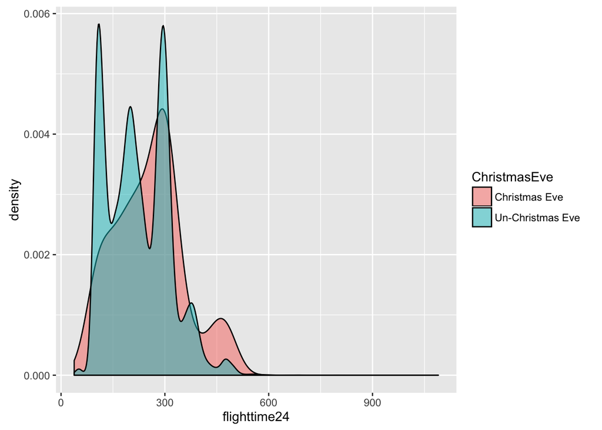

```r
ggplot(flightscomparison, aes(flighttime24, group = ChristmasEve, fill= ChristmasEve ))+geom_density(alpha=.5)
```

This is a bit hard to read, so lets cut out all flights more than 6 hours, note that we are putting the filter command right into the ggplot command.

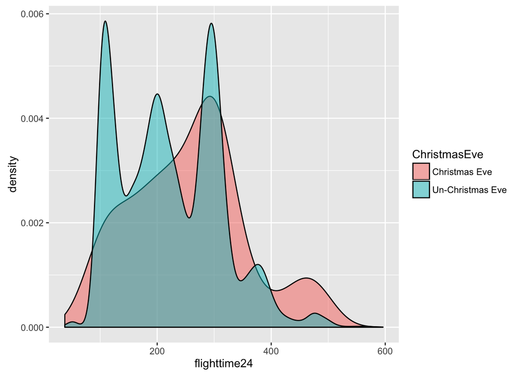

```r
ggplot(filter(flightscomparison, flighttime24<600), aes(flighttime24, group = ChristmasEve, fill= ChristmasEve ))+geom_density(alpha=.5)
```

For your enjoyment, I am going to add some features to the plot above, to make it look nice.

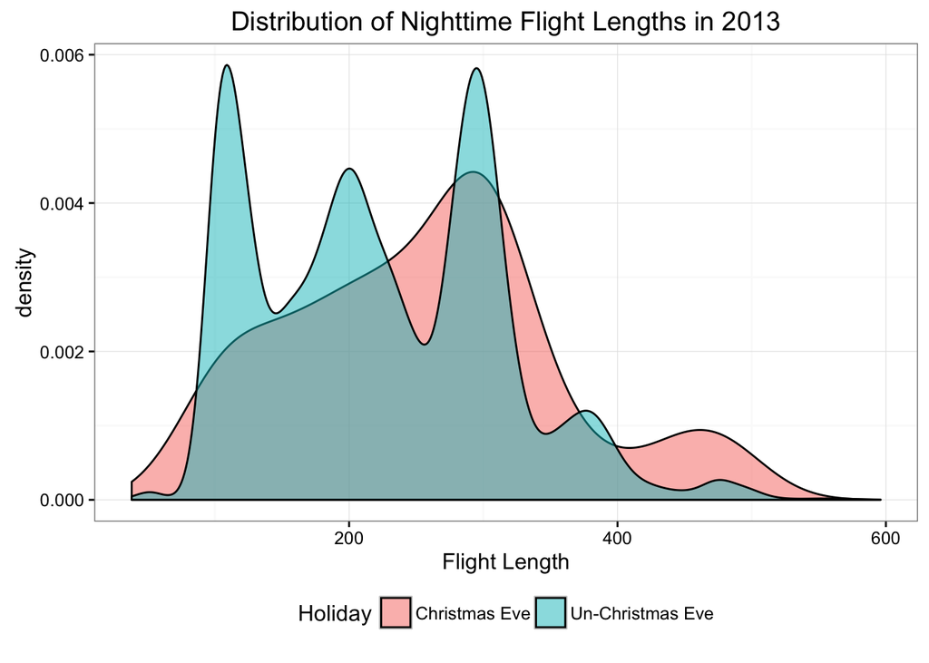

```r
ggplot(filter(flightscomparison, flighttime24<600), aes(flighttime24, group = ChristmasEve, fill= ChristmasEve ))+
geom_density(alpha=.5)+
theme_bw()+
xlab("Flight Length")+
ggtitle("Distribution of Nighttime Flight Lengths in 2013")+
guides(fill = guide_legend(title = "Holiday"))+theme(legend.position="bottom")
```

## ASSIGNMENT:

Make your favorite plot of the data, and save it using the following commands, with your file location in the pdf command. You will have to replace this path with your preferred path. Turn it in with one paragraph explanation for what you find for full credit.

Lets save this data that we made to do statistical inference later in the quarter. Again, put the path in a folder on your computer.

```r
write.csv(flightscomparison, "~/Google Drive/ChicagoSyllabi/SSI131/Rcode/flightcomparison.csv")
```